# Study of the predictive ability of immunological status and clustering features on the development of chronic graft-versus-host disease after allogeneic hematopoietic stem cell transplantation.

Elena Marochkina

2024-12-18

```r
library(dplyr)
```

```r
library(stringr)
library(tidyr)
library(flextable)
library(officer)
library(tibble)
library(ggplot2)
library(reshape2)
library(pheatmap)
library(caret)
library(corrplot)
library(randomForestSRC)
library(survival)
library(Boruta)
```

# 1. Read and Clean Data

```r
# Read data and rename columns
df <- read.csv("../../raw_data/AI_Tcells_для ЕА - Sheet1.csv")

# Check duplicates
duplicates <- df %>%
  group_by(ID, Time_OS, cGVHD_time, Names) %>%
  filter(n() > 1) %>%
  ungroup()

# Clean the data
df_clean <- df %>%
  mutate(
    Abs_Value = as.numeric(str_replace_all(Abs_Value, ",", ".")),
    Abs_Value = as.numeric(Abs_Value)) %>%
  # Rename columns
  rename(
    Subject_ID = ID,
    Observation_Days_Count = Time_OS,
    cGVHD_Diagnosis_Day = cGVHD_time,
    Cell_Count = Abs_Value
  ) %>%
  mutate(
    # Add flag to indicate which patients experienced cGVHD
    cGVHD_flag = as.numeric(ifelse(!is.na(cGVHD_Diagnosis_Day), 1, 0)),
    Subject_ID = as.factor(Subject_ID),

    # Add blood test group
    Blood_test_day = case_when(
      grepl('ДЕНЬ ХРРТПХ_ПЕР.КРОВЬ', df$Names) ~ "cGVHD",
      grepl('ДЕНЬ ХРРТПХ +', df$Names) ~ paste0(str_extract(df$Names, "(?<=\\+)\\d+(?=_)"), "_cGVHD"),
      TRUE ~ str_extract(df$Names, "(?<=\\+)\\d+(?=_)")
    ),

    # Create exact cell name
    Cell_name = str_extract(Names, "(?<=/).*")
  ) %>%
  select(-Names)

unify_cell_name <- function(cell_name, replacements) {
  cell_name_unified <- cell_name
  for (replacement in replacements) {
    old_value <- replacement[1]
    new_value <- replacement[2]

    old_value <- str_replace_all(old_value, "([\\+\\*\\?\\|\\(\\)\\[\\]\\{\\}\\^\\$\\.])", "\\\\\\1")
    cell_name_unified <- str_replace_all(cell_name_unified, old_value, new_value)
  }
  return(cell_name_unified)
}

replacements <- list(
  c("PD1", "PD-1"),
  c("СТАР2", "STAR2"),
  c("4", "CD4_"),
  c("CD4_+", "CD4+_"),
  c("8", "CD8_"),
  c("CD8_+", "CD8+_"),
  c("Th", "TH"),
  c("__", "_"),
  c("_ ", "_")
)

# Apply the function to dataframe
df_clean <- df_clean %>%
  mutate(
    Cell_name_unified = Cell_name,
    Cell_name_unified = unify_cell_name(Cell_name, replacements)
    )

# Check for duplicates for control
duplicates <- df_clean %>%
  group_by(Subject_ID, Observation_Days_Count, cGVHD_Diagnosis_Day, cGVHD_flag, Blood_test_day, Cell_name) %>%
  filter(n() > 1) %>%
  ungroup()

# Check the unique cells name
unique_cells_name <- unique(df_clean$Cell_name_unified)
print(unique_cells_name)
```

```
##   [1] "CD4_TFH"              "CD4_TH1"              "CD4_TH17"
##   [4] "CD4_TH17TO1"          "CD4_TH2"              "CD4_TH22"
##   [7] "CD4+_(IM STAT)"       "CD4+_"                "CD4+_226+"
##  [10] "CD4+_39+"             "CD4+_DR+"             "CD4+_PD-1+"
##  [13] "CD4+_PD-1+TIGIT-"     "CD4+_PD-1+TIGIT+"     "CD4+_PD-1-TIGIT-"
##  [16] "CD4+_PD-1-TIGIT+"     "CD4+_TIGIT+"          "CD4_NV(STAR2)"
##  [19] "CD4_NV"               "CD4_NV_TH1"           "CD4_NV_TH17"
##  [22] "CD4_NV_TH17TO1"       "CD4_NV_TH2"           "CD4_NV_TH22"
##  [25] "CD4_NV+226+"          "CD4_NV+39+"           "CD4_NV+DR+"
##  [28] "CD4_NV+PD-1+"         "CD4_NV+PD-1+TIGIT-"   "CD4_NV+PD-1+TIGIT+"
##  [31] "CD4_NV+PD-1-TIGIT-"   "CD4_NV+PD-1-TIGIT+"   "CD4_NV+TIGIT+"
##  [34] "CD4_ЕМ"               "CD4_ЕМ_TH1"           "CD4_ЕМ_TH17"
##  [37] "CD4_ЕМ_TH17TO1"       "CD4_ЕМ_TH2"           "CD4_ЕМ_TH22"
##  [40] "CD4_ЕМ+226+"          "CD4_ЕМ+39+"           "CD4_ЕМ+DR+"
##  [43] "CD4_ЕМ+PD-1+"         "CD4_ЕМ+PD-1+TIGIT-"   "CD4_ЕМ+PD-1+TIGIT+"
```

[output cut: 40 more lines]

```r
rm(duplicates, replacements, unify_cell_name)
```

**Crucial steps:**

1. cGVHD Flag: Adds a flag (cGVHD_flag) to indicate if a patient experienced chronic GVHD (1 if cGVHD_Diagnosis_Day is not NA, otherwise 0).
2. Blood Test Timing: classifies the blood test timing into groups (e.g., cGVHD, +30_cGVHD).
3. Cell Name Parsing: Extracts the exact immune cell name from the Names column.
4. Defines a function unify_cell_name to standardize cell names using a list of replacements (e.g., PD1 -> PD-1, 4 -> CD4_).

## 1.1. Rearrange Data

```r
# Check the number of unique days
unique_days <- unique(df_clean$Blood_test_day)
print(unique_days)
```

```
##  [1] "180"       "30"        "365"       "60"        "90"        "180_cGVHD"
##  [7] "30_cGVHD"  "60_cGVHD"  "90_cGVHD"  "cGVHD"
```

```r
# Transform the dataframe
df_transformed <- df_clean %>%
  group_by(Subject_ID, Blood_test_day) %>%
  pivot_wider(
    id_cols = c(Subject_ID, Observation_Days_Count, cGVHD_Diagnosis_Day, cGVHD_flag, Blood_test_day),
    names_from = Cell_name_unified,
    values_from = Cell_Count,
    values_fill = list(Cell_Count = NA)
  ) %>%
  ungroup()

# Check if in any cell contain more than 1 number
multi_value_cells <- apply(df_transformed, 2, function(column) {
  any(grepl(",", column, fixed = TRUE) | grepl(" ", column))
})

contains_multiple_values <- ifelse(any(multi_value_cells), "Yes", "No")
print(contains_multiple_values)
```

```
## [1] "Yes"
```

```r
rm(unique_days, contains_multiple_values)
```

**Crucial steps:**

# 2. Prediction of cGVHD outcome

## 2.1. Define DataSet

Survival Analysis are planned.

*Event:* Diagnosis of cGVHD (cGVHD_flag == 1).

*Survival Time:*

- For patients with cGVHD: cGVHD_Diagnosis_Day as the survival time.
- For patients without cGVHD: Observation_Days_Count as the censored survival time.

*Perform PCA to reduce 167 variables into fewer components that explain the maximum variance!*

```r
# Select days of interest
df_cGVHD_prediction <- df_transformed %>%
  filter(Blood_test_day %in% c("90", "180", "365", "cGVHD"))

# # Apply log transformation to numeric columns
# df_cGVHD_prediction <- df_cGVHD_prediction %>%
#  mutate(
#     Observation_Days_Count = factor(Observation_Days_Count),
#     cGVHD_Diagnosis_Day = factor(cGVHD_Diagnosis_Day)
#   ) %>%
#   mutate(across(
#     where(is.numeric),
#     ~ log10(. + 1),
#     .names = "{col}"
#   )) %>%
#   mutate(
#     Observation_Days_Count = as.numeric(Observation_Days_Count),
#     cGVHD_Diagnosis_Day = as.numeric(cGVHD_Diagnosis_Day)
#   )
```

## 2.2. Check for Missing Data

```r
# Calculate missing values by Blood_test_day
missing_summary <- df_cGVHD_prediction %>%
  group_by(Blood_test_day) %>%
  summarise(across(everything(), ~ mean(is.na(.)) * 100)) %>%
  pivot_longer(cols = -Blood_test_day, names_to = "Column", values_to = "Missing_Percentage")
```

**Crucial steps:**

1. No missing values by Blood test day were identified for any cell name.

## 2.3. Visualisation

### 2.3.1. Correlation martrix

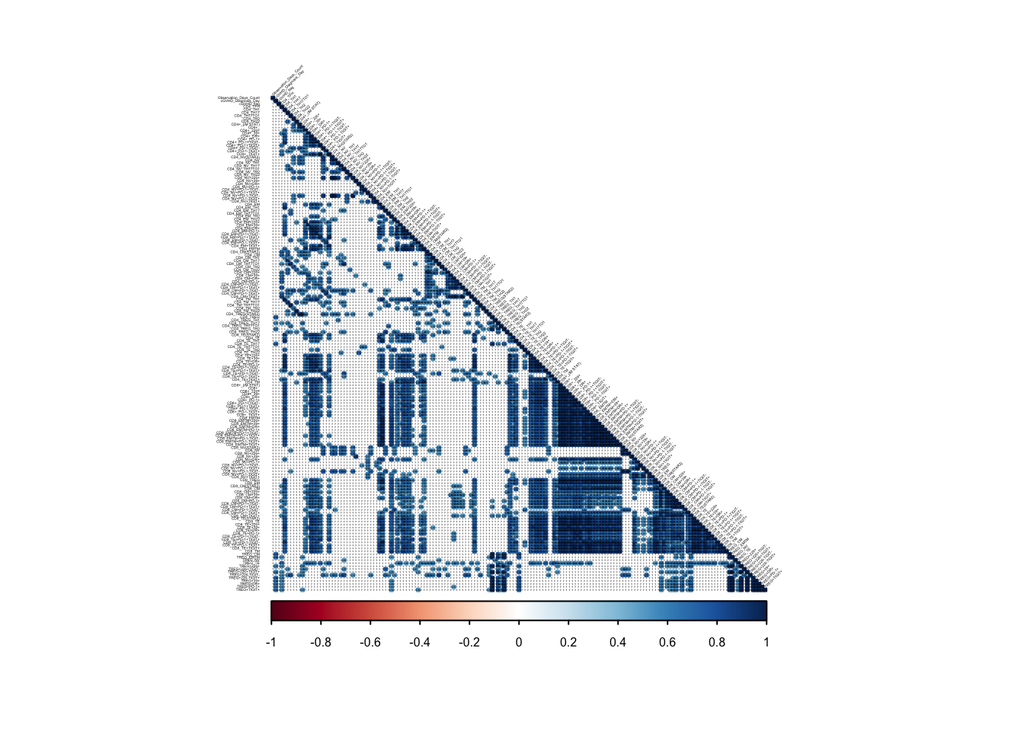

```r
# Select relevant numeric columns
correlation_data <- df_cGVHD_prediction %>%
  filter(Blood_test_day %in% c("90")) %>%
  filter(cGVHD_Diagnosis_Day > 90 | is.na(cGVHD_Diagnosis_Day)) %>%
  select(where(is.numeric))

cor_matrix <- cor(correlation_data, use = "complete.obs")

# Mask weak correlations
cor_matrix[abs(cor_matrix) < 0.5] <- NA

# Plot strong correlations
corrplot(cor_matrix,
         method = "color",
         type = "lower",
         tl.col = "black",
         tl.srt = 45,
         number.cex = 0.1,
         addCoef.col = "black",
         mar = c(2, 2, 2, 2),
         cl.cex = 0.5,
         tl.cex = 0.15)
```

```r
correlation_table <- as.data.frame(as.table(cor_matrix))

colnames(correlation_table) <- c("Variable1", "Variable2", "Correlation")

# Filter for correlations >= 0.9
filtered_table <- correlation_table %>%
  filter(Correlation >= 0.9 & Variable1 != Variable2)

# Ensure no duplicate pairs
filtered_table <- filtered_table %>%
  mutate(
    Pair = paste0(pmin(Variable1, Variable2), "-", pmax(Variable1, Variable2))) %>%
  distinct(Pair, .keep_all = TRUE) %>%
  select(-Pair) %>%
  arrange(desc(Correlation)) %>%
  mutate(Num = row_number())

print(filtered_table)
```

```
##                Variable1          Variable2 Correlation Num
## 1     CD4_NV+PD-1-TIGIT-      CD4_NV(STAR2)   0.9988554   1
## 2               CD4_ЕМTM        CD4_ЕМ+226+   0.9987951   2
## 3            CD4_СМ+226+      CD4_СМ(STAR2)   0.9981005   3
## 4         CD8+_(IM STAT)              CD8+_   0.9980909   4
## 5            CD4_ТЕ+226+      CD4_ТЕ(STAR2)   0.9979095   5
## 6          CD4_ТЕ(STAR2)        CD4_ТЕ+226+   0.9979095   6
## 7              CD8+_226+     CD8+_(IM STAT)   0.9971282   7
## 8               CD8+_DR+     CD8+_(IM STAT)   0.9969826   8
## 9            CD8_NV+226+      CD8_NV(STAR2)   0.9958067   9
## 10           CD4+_TIGIT+   CD4+_PD-1+TIGIT+   0.9951071  10
## 11      CD4+_PD-1+TIGIT+        CD4+_TIGIT+   0.9951071  11
## 12           CD4_NV+226+      CD4_NV(STAR2)   0.9930840  12
## 13                CD4_NV      CD4_NV(STAR2)   0.9917729  13
## 14         CD4_NV(STAR2)             CD4_NV   0.9917729  14
```

[output cut: 104 more lines]

```r
# Check correlations for 'cGVHD_Diagnosis_Day' >= 0.6
cgvhd_filtered_table <- correlation_table %>%
  filter(
    (Variable1 == "cGVHD_Diagnosis_Day") &
    Correlation > 0.6 &
    (Variable1 != Variable2)
  ) %>%
  arrange(desc(Correlation)) %>%
  mutate(Num = row_number())

# Print the filtered table
print(cgvhd_filtered_table)
```

```
##              Variable1       Variable2 Correlation Num
## 1  cGVHD_Diagnosis_Day        CD4_ТREG   0.7260422   1
## 2  cGVHD_Diagnosis_Day         TREG_CM   0.7015492   2
## 3  cGVHD_Diagnosis_Day TREG+226-TIGIT+   0.6771389   3
## 4  cGVHD_Diagnosis_Day     CD4_ТЕ_TH17   0.6704323   4
## 5  cGVHD_Diagnosis_Day       TREG_EMTM   0.6595814   5
## 6  cGVHD_Diagnosis_Day        TREG+39+   0.6438838   6
## 7  cGVHD_Diagnosis_Day     TREG+TIGIT+   0.6366662   7
## 8  cGVHD_Diagnosis_Day        TREG+DR+   0.6325147   8
## 9  cGVHD_Diagnosis_Day      TREG+PD-1+   0.6125532   9
## 10 cGVHD_Diagnosis_Day    CD4_ТREG_TH2   0.6125443  10
```

- In linear regression or logistic regression, multicollinearity makes it difficult to determine the unique contribution of each predictor variable.

Models that are not sensitive to multicollinearity because they split the data hierarchically:

- *Random Forest:*
- *XGBoost*

### 2.3.2. Heatmap with clusters

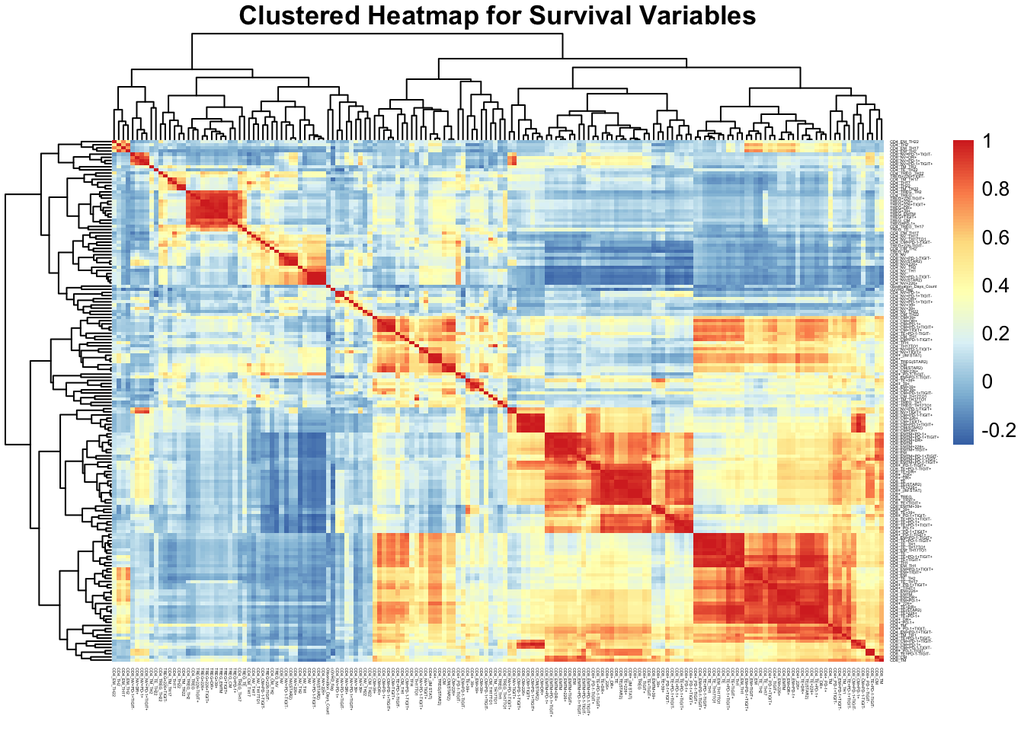

```r
correlation_data <- df_cGVHD_prediction %>%
  filter(Blood_test_day %in% c("90")) %>%
  filter(cGVHD_Diagnosis_Day > 90 | is.na(cGVHD_Diagnosis_Day)) %>%
  select(where(is.numeric), -cGVHD_Diagnosis_Day)

cor_matrix <- cor(correlation_data, use = "complete.obs")

# Hierarchical clustering and heatmap
pheatmap(cor_matrix,
         cluster_rows = TRUE,
         cluster_cols = TRUE,
         display_numbers = FALSE,
         fontsize_row = 2,
         fontsize_col = 2,
         main = "Clustered Heatmap for Survival Variables",
         width = 20,
        height = 20  )
```

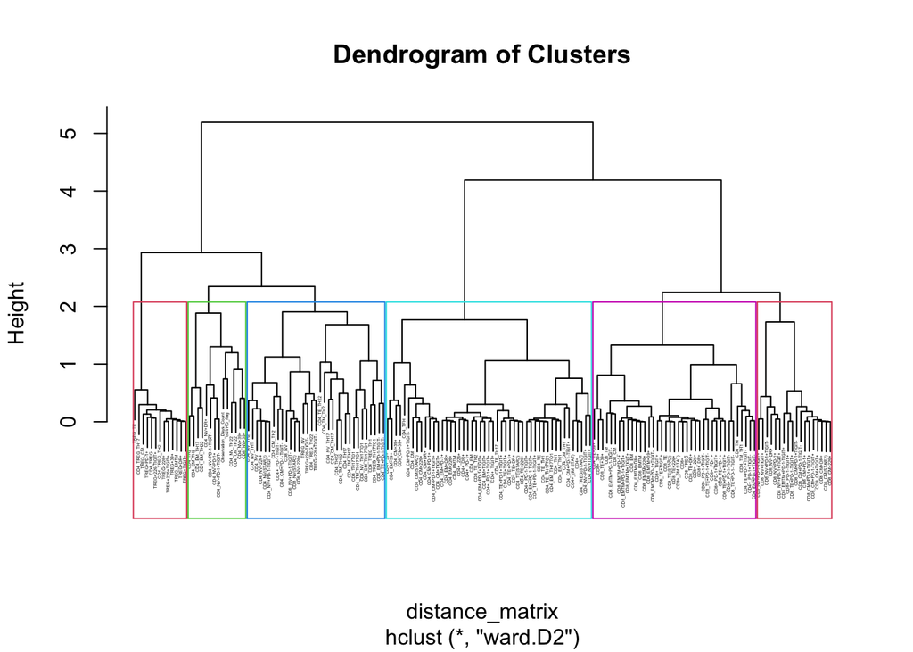

```r
# Perform hierarchical clustering
distance_matrix <- as.dist(1 - cor_matrix)
hclust_result <- hclust(distance_matrix, method = "ward.D2") # Ward's method

# Cut the dendrogram into clusters
clusters <- cutree(hclust_result, k = 6)

clustered_data <- data.frame(
  Variable = rownames(cor_matrix),
  Cluster = clusters
)

# Dendrogram with clusters
plot(hclust_result, labels = rownames(cor_matrix), main = "Dendrogram of Clusters", cex = 0.2)

# Add rectangles
rect.hclust(hclust_result, k = 6, border = 2:6)
```

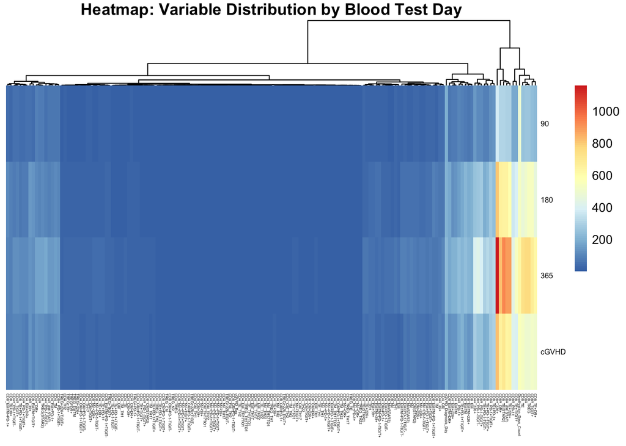

```r
custom_order <- c("90", "180", "365", "cGVHD")

# Convert Blood_test_day to a factor with the custom order
df_cGVHD_transformed <- df_cGVHD_prediction %>%
  mutate(Blood_test_day = factor(Blood_test_day, levels = custom_order))

# Arrange data by the specified order of Blood_test_day
df_cGVHD_transformed <- df_cGVHD_transformed %>%
  arrange(Blood_test_day)

# Aggregate data by Blood_test_day
heatmap_data <- df_cGVHD_transformed %>%
  group_by(Blood_test_day) %>%
  summarise(across(where(is.numeric), mean, na.rm = TRUE)) %>%
  ungroup()

# Convert to matrix for heatmap plotting
heatmap_matrix <- heatmap_data %>%
  column_to_rownames("Blood_test_day") %>%
  as.matrix()

# Create the heatmap
pheatmap(heatmap_matrix,
         cluster_rows = FALSE,
         cluster_cols = TRUE,
         display_numbers = FALSE,
         fontsize_row = 6,
         fontsize_col = 3,
         main = "Heatmap: Variable Distribution by Blood Test Day")
```

Some variable distributions seem to change over time (Blood Test Day), with certain groups (e.g., those in warmer tones) showing higher activity at specific days, such as 365 (for non-log-transformed data).

### 2.3.3. PCA

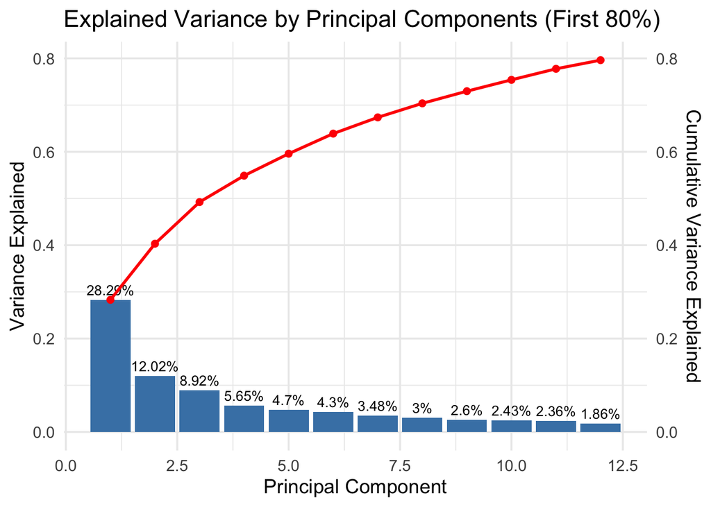

```r
# Filter and normalize data while preserving cGVHD_flag
df_normalized <- df_transformed %>%
  filter(Blood_test_day %in% c("90", "180", "365", "cGVHD")) %>%
  filter(cGVHD_Diagnosis_Day > 90 | is.na(cGVHD_Diagnosis_Day)) %>%
  # Ensure cGVHD_flag is retained for later use
  select(cGVHD_flag, where(is.numeric), -Observation_Days_Count, -cGVHD_Diagnosis_Day) %>%
  mutate(across(where(is.numeric), ~ (.-mean(.)) / sd(.), .names = "z_{col}"))

# Save cGVHD_flag for later use
cGVHD_flags <- df_normalized$cGVHD_flag

# Perform near-zero variance filtering (excluding cGVHD_flag)
nzv <- nearZeroVar(df_normalized %>% select(-cGVHD_flag))
df_filtered <- df_normalized %>%
  select(-nzv, cGVHD_flag) %>% # Retain cGVHD_flag after filtering
  filter(complete.cases(.))

# Perform PCA (exclude cGVHD_flag from PCA computation)
pca_results <- prcomp(df_filtered %>% select(-cGVHD_flag), scale. = TRUE)

# Attach PCA scores and cGVHD_flag back together
pca_scores <- as.data.frame(pca_results$x) %>%
  mutate(cGVHD_flag = cGVHD_flags)

# Explained variance calculations
explained_variance <- pca_results$sdev^2 / sum(pca_results$sdev^2)
cumulative_variance <- cumsum(explained_variance)

# Create a data frame for plotting explained variance
explained_variance_data <- data.frame(
  PC = 1:length(explained_variance),
  Explained_Variance = explained_variance,
  Cumulative_Variance = cumulative_variance
)

# Filter for components contributing to the first 80% of cumulative variance
explained_variance_data_filtered <- explained_variance_data %>%
  filter(Cumulative_Variance <= 0.8)

# Add percentage labels for explained variance
explained_variance_data_filtered <- explained_variance_data_filtered %>%
  mutate(Variance_Percentage_Label = paste0(round(Explained_Variance * 100, 2), "%"))

# Plot explained variance with percentage labels
ggplot(explained_variance_data_filtered, aes(x = PC)) +
  geom_bar(aes(y = Explained_Variance), stat = "identity", fill = "steelblue") +
  geom_text(aes(y = Explained_Variance, label = Variance_Percentage_Label),
            vjust = -0.5, size = 3.5) +
  geom_line(aes(y = Cumulative_Variance), color = "red", size = 1) +
  geom_point(aes(y = Cumulative_Variance), color = "red", size = 2) +
  scale_y_continuous(
    name = "Variance Explained",
    sec.axis = sec_axis(~., name = "Cumulative Variance Explained")
  ) +
  labs(
    title = "Explained Variance by Principal Components (First 80%)",
    x = "Principal Component"
  ) +
  theme_minimal(base_size = 14)
```

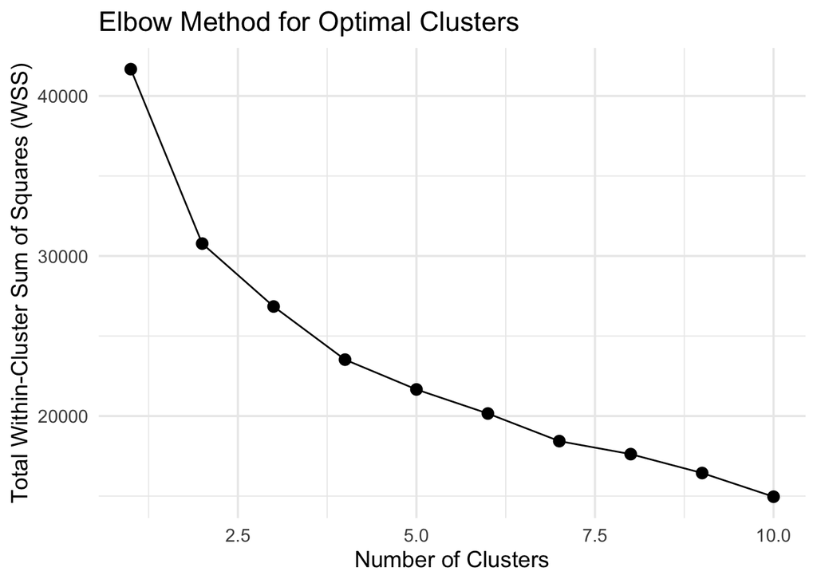

```r
# Perform clustering on PCA scores
set.seed(123)
wss <- sapply(1:10, function(k) {
  kmeans(pca_scores[, 1:10], centers = k, nstart = 25)$tot.withinss
})

# Plot Elbow Method
elbow_plot <- data.frame(Clusters = 1:10, WSS = wss)
ggplot(elbow_plot, aes(x = Clusters, y = WSS)) +
  geom_line() +
  geom_point(size = 3) +
  labs(
    title = "Elbow Method for Optimal Clusters",
    x = "Number of Clusters",
    y = "Total Within-Cluster Sum of Squares (WSS)"
  ) +
  theme_minimal(base_size = 14)
```

```
## Too few points to calculate an ellipse
```

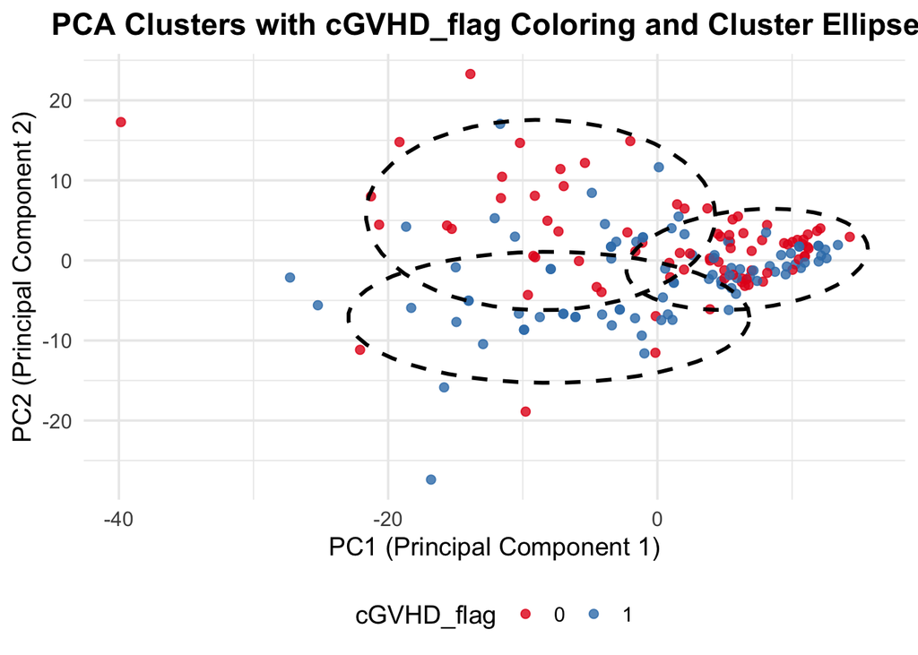

```r
# Apply K-means clustering
optimal_clusters <- 4
kmeans_result <- kmeans(pca_scores[, 1:10], centers = optimal_clusters, nstart = 25)
pca_scores$Cluster <- as.factor(kmeans_result$cluster)

# Visualize clusters with coloring by cGVHD_flag
ggplot(pca_scores, aes(x = PC1, y = PC2, color = as.factor(cGVHD_flag))) +
  geom_point(size = 2, alpha = 0.8) +  # Scatterplot of PCA points
  stat_ellipse(aes(group = Cluster), type = "t", linetype = "dashed", size = 1, color = "black") +  # Ellipses for clusters
  scale_color_brewer(palette = "Set1") +  # Color palette for cGVHD_flag
  labs(
    title = "PCA Clusters with cGVHD_flag Coloring and Cluster Ellipses",
    x = "PC1 (Principal Component 1)",
    y = "PC2 (Principal Component 2)",
    color = "cGVHD_flag"
  ) +
  theme_minimal(base_size = 14) +
  theme(
    legend.position = "bottom",
    plot.title = element_text(face = "bold", hjust = 0.5)
  )
```

### 2.3.4. BORUTA algorithm

#### 2.3.4.1. 90 days

```r
set.seed(123)

df_boruta_90 <- df_transformed %>%
  filter(Blood_test_day %in% c("90")) %>%
  filter(cGVHD_Diagnosis_Day > 90 | is.na(cGVHD_Diagnosis_Day)) %>%
  select(-Observation_Days_Count, -cGVHD_Diagnosis_Day, -Blood_test_day, -Subject_ID)

# Apply the Boruta algorithm
boruta_result_90 <- Boruta(cGVHD_flag ~ ., data = df_boruta_90)

# Extract important variables
important_vars_90 <- getSelectedAttributes(boruta_result_90, withTentative = FALSE)

# Extract tentative variables
tentative_vars_90 <- getSelectedAttributes(boruta_result_90, withTentative = TRUE)
only_tentative_90 <- setdiff(tentative_vars_90, important_vars_90)

cat("Confirmed important variables:\n", paste(important_vars_90, collapse = ", "), "\n\n")
```

```
## Confirmed important variables:
##  CD4_СМ_TH2, CD4_СМ_TH22, CD8_EMTM+DR+, CD8_EMTM+PD-1+, CD8_EMTM+PD-1+TIGIT+, CD8_EMTM+TIGIT+
```

```r
cat("Tentative variables:\n", paste(only_tentative_90, collapse = ", "), "\n")
```

```
## Tentative variables:
##  CD8+_, CD8_EMTM, CD8_EMTM+226+
```

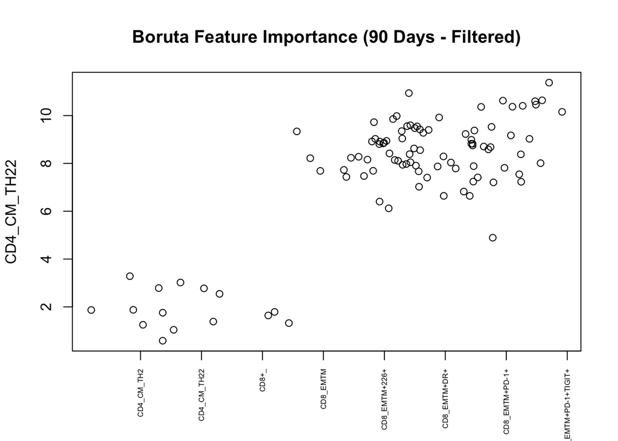

```r
# keep only important and tentative features
filtered_importance <- boruta_result_90$ImpHistory[, tentative_vars_90, drop = FALSE]

# Plot filtered results
plot(filtered_importance, xlab = "", xaxt = "n", main = "Boruta Feature Importance (90 Days - Filtered)")
lz <- lapply(1:ncol(filtered_importance), function(i) filtered_importance[, i])
names(lz) <- colnames(filtered_importance)
axis(side = 1, las = 2, labels = names(lz),
     at = 1:ncol(filtered_importance), cex.axis = 0.5)
```

#### 3.3.4.2. 180 days

```r
set.seed(123)

df_boruta_180 <- df_transformed %>%
  filter(Blood_test_day %in% c("180")) %>%
  filter(cGVHD_Diagnosis_Day > 180 | is.na(cGVHD_Diagnosis_Day)) %>%
  select(-Observation_Days_Count, -cGVHD_Diagnosis_Day, -Blood_test_day, -Subject_ID)

# Apply the Boruta algorithm
boruta_result_180 <- Boruta(cGVHD_flag ~ ., data = df_boruta_180)

# Extract important variables
important_vars_180 <- getSelectedAttributes(boruta_result_180, withTentative = FALSE)

# Extract tentative variables
tentative_vars_180 <- getSelectedAttributes(boruta_result_180, withTentative = TRUE)
only_tentative_180 <- setdiff(tentative_vars_180, important_vars_180)

cat("Confirmed important variables:\n", paste(important_vars_180, collapse = ", "), "\n\n")
```

```
## Confirmed important variables:
##  CD4_NV_TH1, CD4_NV+226+, CD4_ТЕ+PD-1+TIGIT+
```

```r
cat("Tentative variables:\n", paste(only_tentative_180, collapse = ", "), "\n")
```

```
## Tentative variables:
##  CD4_ТЕ, CD4_ТЕ+TIGIT+, CD8_СМ+TIGIT+, TREG+226+TIGIT-
```

[figure not shown]

```r
# keep only important and tentative features
filtered_importance <- boruta_result_180$ImpHistory[, tentative_vars_180, drop = FALSE]

# Plot filtered results
plot(filtered_importance, xlab = "", xaxt = "n", main = "Boruta Feature Importance (90 Days - Filtered)")
lz <- lapply(1:ncol(filtered_importance), function(i) filtered_importance[, i])
names(lz) <- colnames(filtered_importance)
axis(side = 1, las = 2, labels = names(lz),
     at = 1:ncol(filtered_importance), cex.axis = 0.5)
```

### 2.3.5. Random Forest over Survival

#### 2.3.5.1 90 days

```r
df_cGVHD_prediction_survival_90 <- df_cGVHD_prediction %>%
  filter(Blood_test_day %in% c("90")) %>%
  filter(cGVHD_Diagnosis_Day > 90 | is.na(cGVHD_Diagnosis_Day)) %>%
  mutate(
    cGVHD_Diagnosis_Day = ifelse(is.na(cGVHD_Diagnosis_Day), Observation_Days_Count, cGVHD_Diagnosis_Day),
    cGVHD_flag = as.numeric(as.character(cGVHD_flag))
  ) %>%
  select(-Subject_ID, -Blood_test_day, -Observation_Days_Count)
```

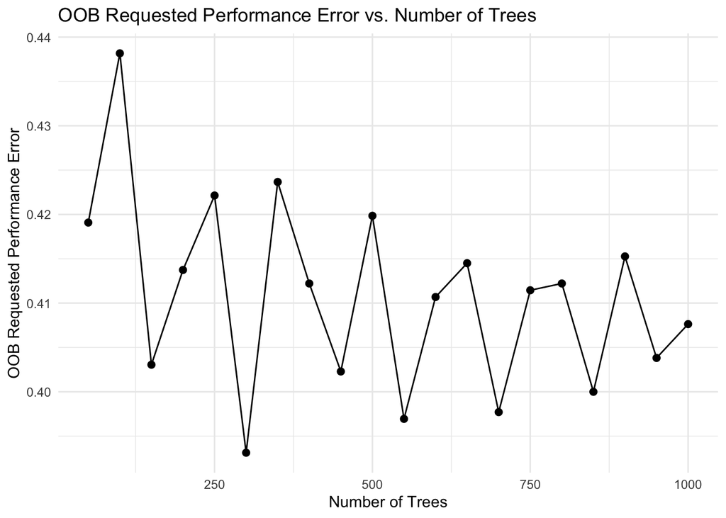

```r
# Function to evaluate OOB Requested performance error for different numbers of trees
evaluate_trees <- function(data, formula, max_trees = 1000, step = 50) {
  results <- data.frame(Trees = integer(), OOB_Error = numeric())

  for (ntree in seq(50, max_trees, by = step)) {
    set.seed(123)
    rf_model <- rfsrc(
      formula = formula,
      data = data,
      mtry = round(sqrt(ncol(data) - 2)),
      nodesize = 15,
      ntree = ntree,
      importance = TRUE
    )

    # Extract the OOB Requested performance error
    oob_error <- rf_model$err.rate[length(rf_model$err.rate)]
    results <- rbind(results, data.frame(
      Trees = ntree,
      OOB_Error = oob_error
    ))
  }

  return(results)
}

# Apply the function to your dataset
oob_results <- evaluate_trees(
  data = df_cGVHD_prediction_survival_90,
  formula = Surv(cGVHD_Diagnosis_Day, cGVHD_flag) ~ .,
  max_trees = 1000,
  step = 50
)

ggplot(oob_results, aes(x = Trees, y = OOB_Error)) +
  geom_line() +
  geom_point(size = 2) +
  labs(
    title = "OOB Requested Performance Error vs. Number of Trees",
    x = "Number of Trees",
    y = "OOB Requested Performance Error"
  ) +
  theme_minimal()
```

```r
# Find the number of trees with the minimum OOB error
best_trees <- oob_results$Trees[which.min(oob_results$OOB_Error)]

print(paste("Best number of trees:", best_trees))
```

```
## [1] "Best number of trees: 300"
```

```r
# Build the Random Survival Forest model
RF_obj <- rfsrc(Surv(cGVHD_Diagnosis_Day,cGVHD_flag)~.,
                df_cGVHD_prediction_survival_90,
                ntree = best_trees,
                mtry = round(sqrt(ncol(df_cGVHD_prediction_survival_90) - 2)),
                nodesize = 15,
                membership = TRUE,
                importance=TRUE)

# Print the Random Survival Forest object
print(RF_obj)
```

```
##                          Sample size: 66
##                     Number of deaths: 27
##                      Number of trees: 300
##            Forest terminal node size: 15
##        Average no. of terminal nodes: 4.29
## No. of variables tried at each split: 13
##               Total no. of variables: 164
##        Resampling used to grow trees: swor
##     Resample size used to grow trees: 42
##                             Analysis: RSF
##                               Family: surv
##                       Splitting rule: logrank *random*
##        Number of random split points: 10
##                           (OOB) CRPS: 75.93036705
##                    (OOB) stand. CRPS: 0.15125571
##    (OOB) Requested performance error: 0.39923664
```

The raw CRPS (75.93) and standardized CRPS (0.151) measure how accurate the model’s predictions are. Lower values mean better predictions.

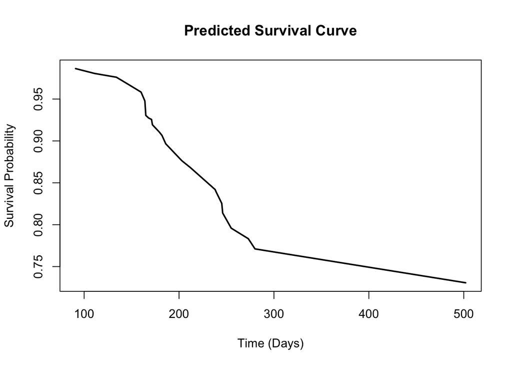

```r
# Create a hypothetical observation for prediction
# Creating an hypothetical observation
newdata <- data.frame(lapply(1:ncol(RF_obj$xvar),function(i){median(RF_obj$xvar[,i])}))
colnames(newdata) <- RF_obj$xvar.names

# Predict survival for the hypothetical observation
y.pred <- predict(RF_obj, newdata = rbind(newdata, RF_obj$xvar)[1, ])

# Plot predicted survival probability over time

plot(
  round(y.pred$time.interest, 2),
  y.pred$survival[1, ],
  type = "l",
  xlab = "Time (Days)",
  ylab = "Survival Probability",
  col = 1,
  lty = 1,
  lwd = 2,
  main = "Predicted Survival Curve"
)
```

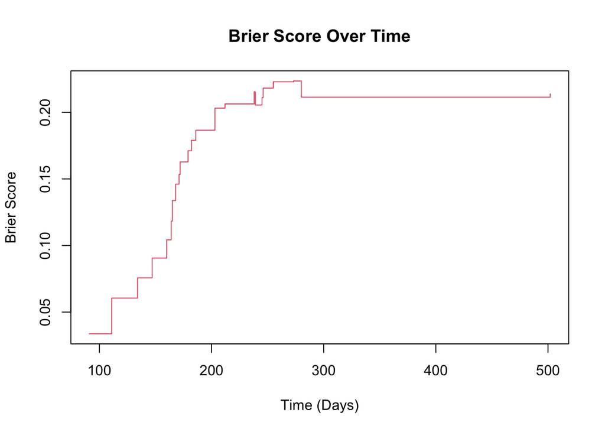

```r
# Calculate the Brier score using the Kaplan-Meier censoring distribution
bs.km <- get.brier.survival(RF_obj, cens.mode = "km")$brier.score

# Plot the Brier score
plot(
  bs.km,
  type = "s",
  col = 2,
  ylab = "Brier Score",
  xlab = "Time (Days)",
  main = "Brier Score Over Time"
)
```

- < 0.1 - excellent
- <= 0.2 - superior
- <=0.3 - adequate

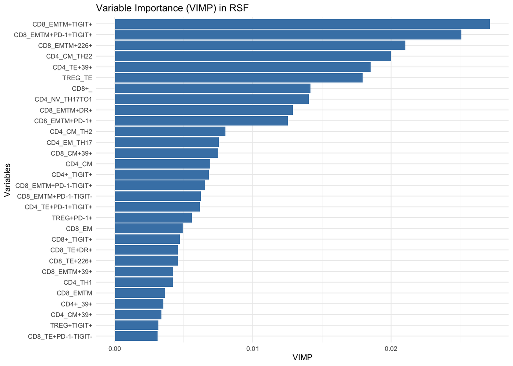

```r
# Extract VIMP
vimp <- RF_obj$importance

vimp_df <- data.frame(
  Variable = names(vimp),
  VIMP = vimp
)

# Sort variables by VIMP in descending order
vimp_df_positive <- vimp_df %>%
  filter(VIMP > 0) %>%
  arrange(desc(VIMP)) %>%
  head(30)

ggplot(vimp_df_positive, aes(x = reorder(Variable, VIMP), y = VIMP)) +
  geom_bar(stat = "identity", fill = "steelblue") +
  coord_flip() +
  labs(
    title = "Variable Importance (VIMP) in RSF",
    x = "Variables",
    y = "VIMP"
  ) +
  theme_minimal(base_size = 8)
```

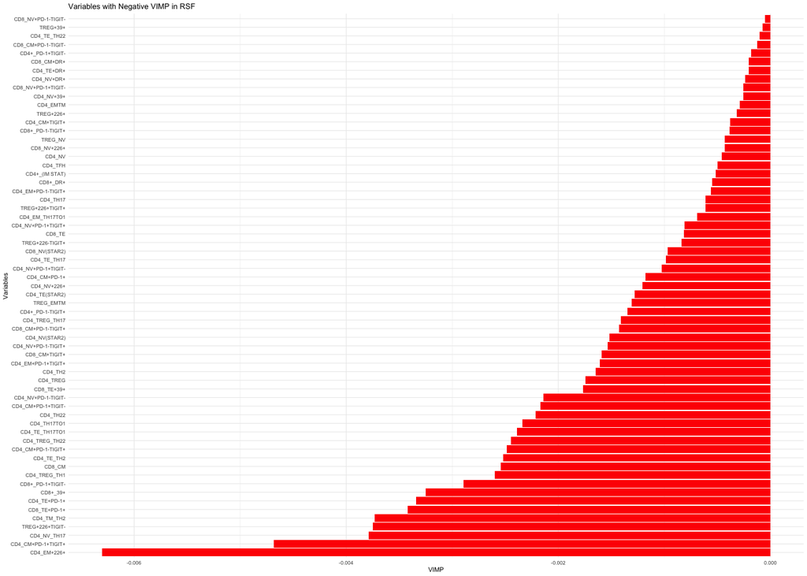

```r
# Filter for variables with negative VIMP
vimp_negative <- vimp_df %>%
  filter(VIMP < 0) %>%
  arrange(VIMP)  # Sort in ascending order

ggplot(vimp_negative, aes(x = reorder(Variable, VIMP), y = VIMP)) +
  geom_bar(stat = "identity", fill = "red") +
  coord_flip() +
  labs(
    title = "Variables with Negative VIMP in RSF",
    x = "Variables",
    y = "VIMP"
  ) +
  theme_minimal(base_size = 4)
```

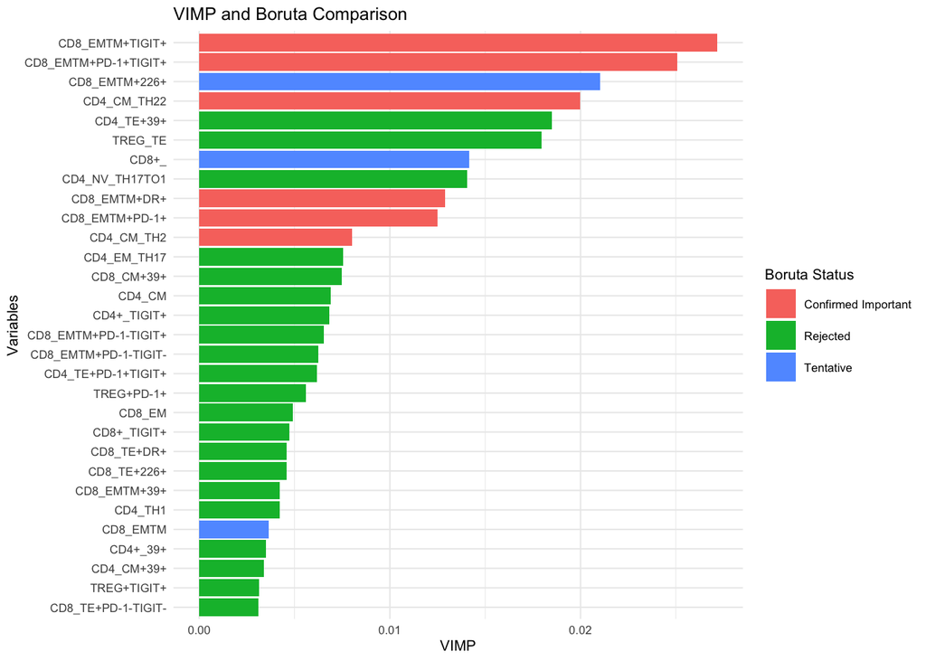

```r
# Compare with VIMP
vimp_boruta_comparison <- vimp_df_positive %>%
  mutate(
    Boruta_Status = case_when(
      Variable %in% important_vars_90 ~ "Confirmed Important",
      Variable %in% only_tentative_90 ~ "Tentative",
      TRUE ~ "Rejected"
    )
  )

# Plot Comparison
ggplot(vimp_boruta_comparison, aes(x = reorder(Variable, VIMP), y = VIMP, fill = Boruta_Status)) +
  geom_bar(stat = "identity") +
  coord_flip() +
  labs(
    title = "VIMP and Boruta Comparison",
    x = "Variables",
    y = "VIMP",
    fill = "Boruta Status"
  ) +
  theme_minimal(base_size = 8)
```

```r
# Print Final Comparison Table
print(vimp_boruta_comparison)
```

```
##                                  Variable        VIMP       Boruta_Status
## CD8_EMTM+TIGIT+           CD8_EMTM+TIGIT+ 0.027171509 Confirmed Important
## CD8_EMTM+PD-1+TIGIT+ CD8_EMTM+PD-1+TIGIT+ 0.025092246 Confirmed Important
## CD8_EMTM+226+               CD8_EMTM+226+ 0.021022865           Tentative
## CD4_СМ_TH22                   CD4_СМ_TH22 0.019995483 Confirmed Important
## CD4_ТЕ+39+                     CD4_ТЕ+39+ 0.018514790            Rejected
## TREG_TE                           TREG_TE 0.017941367            Rejected
## CD8+_                               CD8+_ 0.014151917           Tentative
## CD4_NV_TH17TO1             CD4_NV_TH17TO1 0.014041404            Rejected
## CD8_EMTM+DR+                 CD8_EMTM+DR+ 0.012892669 Confirmed Important
## CD8_EMTM+PD-1+             CD8_EMTM+PD-1+ 0.012517203 Confirmed Important
## CD4_СМ_TH2                     CD4_СМ_TH2 0.008014186 Confirmed Important
## CD4_ЕМ_TH17                   CD4_ЕМ_TH17 0.007563745            Rejected
## CD8_СМ+39+                     CD8_СМ+39+ 0.007473339            Rejected
## CD4_СМ                             CD4_СМ 0.006887344            Rejected
## CD4+_TIGIT+                   CD4+_TIGIT+ 0.006819338            Rejected
## CD8_EMTM+PD-1-TIGIT+ CD8_EMTM+PD-1-TIGIT+ 0.006551614            Rejected
## CD8_EMTM+PD-1-TIGIT- CD8_EMTM+PD-1-TIGIT- 0.006261983            Rejected
## CD4_ТЕ+PD-1+TIGIT+     CD4_ТЕ+PD-1+TIGIT+ 0.006181063            Rejected
## TREG+PD-1+                     TREG+PD-1+ 0.005579094            Rejected
## CD8_ЕМ                             CD8_ЕМ 0.004923155            Rejected
## CD8+_TIGIT+                   CD8+_TIGIT+ 0.004724682            Rejected
## CD8_ТЕ+DR+                     CD8_ТЕ+DR+ 0.004598136            Rejected
## CD8_ТЕ+226+                   CD8_ТЕ+226+ 0.004587730            Rejected
## CD8_EMTM+39+                 CD8_EMTM+39+ 0.004229414            Rejected
## CD4_TH1                           CD4_TH1 0.004216091            Rejected
## CD8_EMTM                         CD8_EMTM 0.003656153           Tentative
## CD4+_39+                         CD4+_39+ 0.003511450            Rejected
## CD4_СМ+39+                     CD4_СМ+39+ 0.003383255            Rejected
## TREG+TIGIT+                   TREG+TIGIT+ 0.003155216            Rejected
## CD8_ТЕ+PD-1-TIGIT-     CD8_ТЕ+PD-1-TIGIT- 0.003093662            Rejected
```

#### 2.3.5.2 180 days

```r
df_cGVHD_prediction_survival_180 <- df_cGVHD_prediction %>%
  filter(Blood_test_day %in% c("180")) %>%
  filter(cGVHD_Diagnosis_Day > 180 | is.na(cGVHD_Diagnosis_Day)) %>%
  mutate(
    cGVHD_Diagnosis_Day = ifelse(is.na(cGVHD_Diagnosis_Day), Observation_Days_Count, cGVHD_Diagnosis_Day),
    cGVHD_flag = as.numeric(as.character(cGVHD_flag))
  ) %>%
  select(-Observation_Days_Count, -Subject_ID, -Blood_test_day)
```

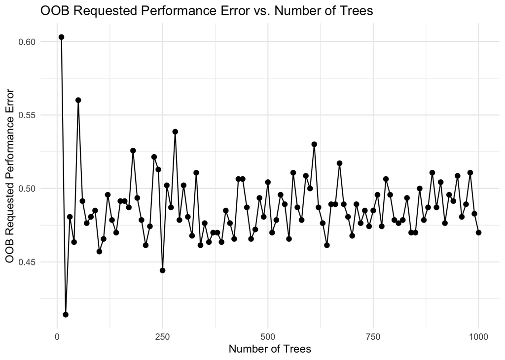

```r
# Function to evaluate OOB Requested performance error for different numbers of trees
evaluate_trees <- function(data, formula, max_trees = 1000, step = 10) {
  results <- data.frame(Trees = integer(), OOB_Error = numeric())

  for (ntree in seq(10, max_trees, by = step)) {
    set.seed(123)
    rf_model <- rfsrc(
      formula = formula,
      data = data,
      mtry = round(sqrt(ncol(data) - 2)),
      nodesize = 7,
      ntree = ntree,
      importance = TRUE
    )

    # Extract the OOB Requested performance error
    oob_error <- rf_model$err.rate[length(rf_model$err.rate)]
    results <- rbind(results, data.frame(
      Trees = ntree,
      OOB_Error = oob_error
    ))
  }

  return(results)
}

# Apply the function to your dataset
oob_results <- evaluate_trees(
  data = df_cGVHD_prediction_survival_180,
  formula = Surv(cGVHD_Diagnosis_Day, cGVHD_flag) ~ .,
  max_trees = 1000,
  step = 10
)

ggplot(oob_results, aes(x = Trees, y = OOB_Error)) +
  geom_line() +
  geom_point(size = 2) +
  labs(
    title = "OOB Requested Performance Error vs. Number of Trees",
    x = "Number of Trees",
    y = "OOB Requested Performance Error"
  ) +
  theme_minimal()
```

```r
# Find the number of trees with the minimum OOB error
best_trees <- oob_results$Trees[which.min(oob_results$OOB_Error)]

print(paste("Best number of trees:", best_trees))
```

```
## [1] "Best number of trees: 20"
```

```r
# Build the Random Survival Forest model
RF_obj <- rfsrc(Surv(cGVHD_Diagnosis_Day,cGVHD_flag)~.,
               df_cGVHD_prediction_survival_180,
                ntree = best_trees,
                mtry = round(sqrt(ncol(df_cGVHD_prediction_survival_180) - 2)),
                nodesize = 15,
                membership = TRUE,
                importance=TRUE)

print(RF_obj)
```

```
##                          Sample size: 42
##                     Number of deaths: 14
##                      Number of trees: 20
##            Forest terminal node size: 15
##        Average no. of terminal nodes: 1
## No. of variables tried at each split: 13
##               Total no. of variables: 164
##        Resampling used to grow trees: swor
##     Resample size used to grow trees: 27
##                             Analysis: RSF
##                               Family: surv
##                       Splitting rule: logrank *random*
##        Number of random split points: 10
##                           (OOB) CRPS: 66.39151602
##                    (OOB) stand. CRPS: 0.13225402
##    (OOB) Requested performance error: 0.86051502
```

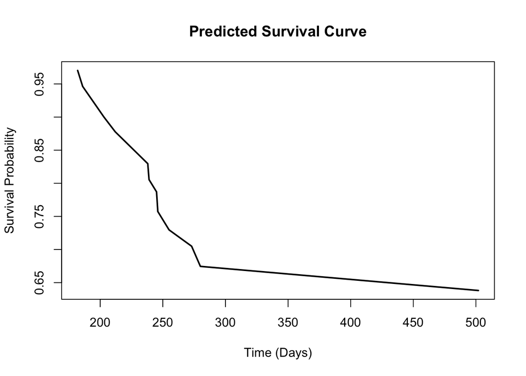

```r
# Create a hypothetical observation for prediction
newdata <- data.frame(lapply(1:ncol(RF_obj$xvar),function(i){median(RF_obj$xvar[,i])}))
colnames(newdata) <- RF_obj$xvar.names

# Predict survival for the hypothetical observation
y.pred <- predict(RF_obj, newdata = rbind(newdata, RF_obj$xvar)[1, ])

# Plot predicted survival probability over time
plot(
  round(y.pred$time.interest, 2),
  y.pred$survival[1, ],
  type = "l",
  xlab = "Time (Days)",
  ylab = "Survival Probability",
  col = 1,
  lty = 1,
  lwd = 2,
  main = "Predicted Survival Curve"
)
```

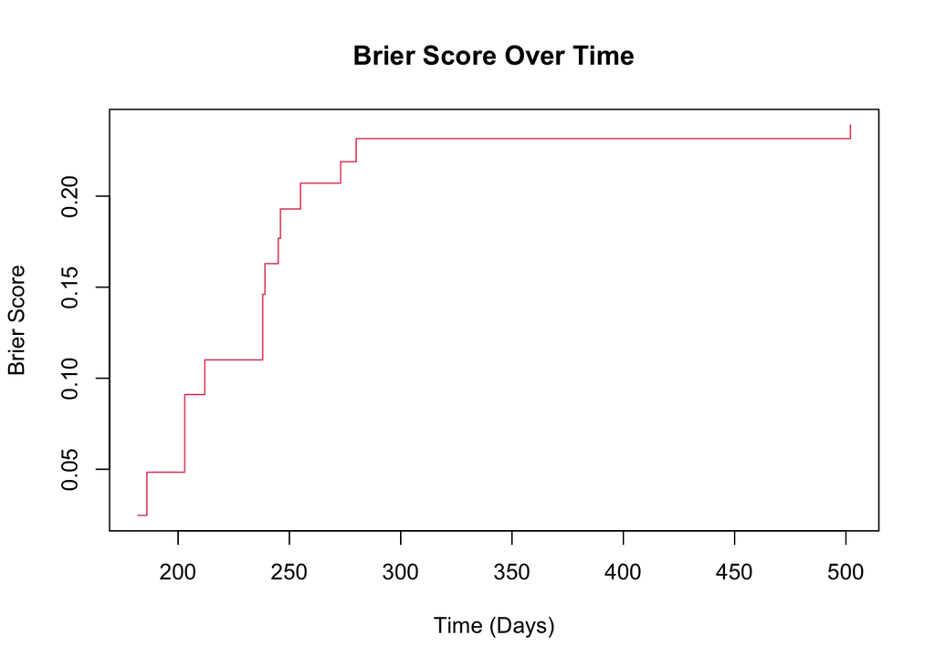

```r
# Calculate the Brier score using the Kaplan-Meier
bs.km <- get.brier.survival(RF_obj, cens.mode = "km")$brier.score

plot(
  bs.km,
  type = "s",
  col = 2,
  ylab = "Brier Score",
  xlab = "Time (Days)",
  main = "Brier Score Over Time"
)
```

- < 0.1 - excellent
- <= 0.2 - superior
- <= 0.3 - adequate

It was not possible to extract VIMP or compare it with Boruta Results. The Model was not good enough to provide good-quality prediction.